# Progetto_demografia

Francesco Gabellini

16 ottobre 2018

Carico librerie

```r
library (demography)
library(devtools)
library(tidyverse)
library(forecast)
library(StMoMo)
set.seed(1234)
```

Importo da HMD

```r
fin <- hmd.mx("FIN", "gabelfra1@hotmail.it", "superorso1", "Finland")
italy <- hmd.mx("ITA", "gabelfra1@hotmail.it", "superorso1", "Italy")
```

## Tavole di mortalità

```r
finf.lt <- lifetable(fin, series = names(fin$rate)[1], years = fin$year, ages = fin$age, max.age = min(110, max(fin$age)), type = c("period"))
finm.lt <- lifetable(fin, series = names(fin$rate)[2], years = fin$year, ages = fin$age, max.age = min(110, max(fin$age)), type = c("period"))
fint.lt <- lifetable(fin, series = names(fin$rate)[3], years = fin$year, ages = fin$age, max.age = min(110, max(fin$age)), type = c("period"))


lifetable_fem <- finf.lt
lifetable_mal <- finm.lt
lifetable_tot <- fint.lt
```

```r
italyf.lt <- lifetable(italy, series = names(italy$rate)[1], years = italy$year, ages = italy$age, max.age = min(110, max(italy$age)), type = c("period"))
italym.lt <- lifetable(italy, series = names(italy$rate)[2], years = italy$year, ages = italy$age, max.age = min(110, max(italy$age)), type = c("period"))
italyt.lt <- lifetable(italy, series = names(italy$rate)[3], years = italy$year, ages = italy$age, max.age = min(110, max(italy$age)), type = c("period"))
```

## Visualizzazione base

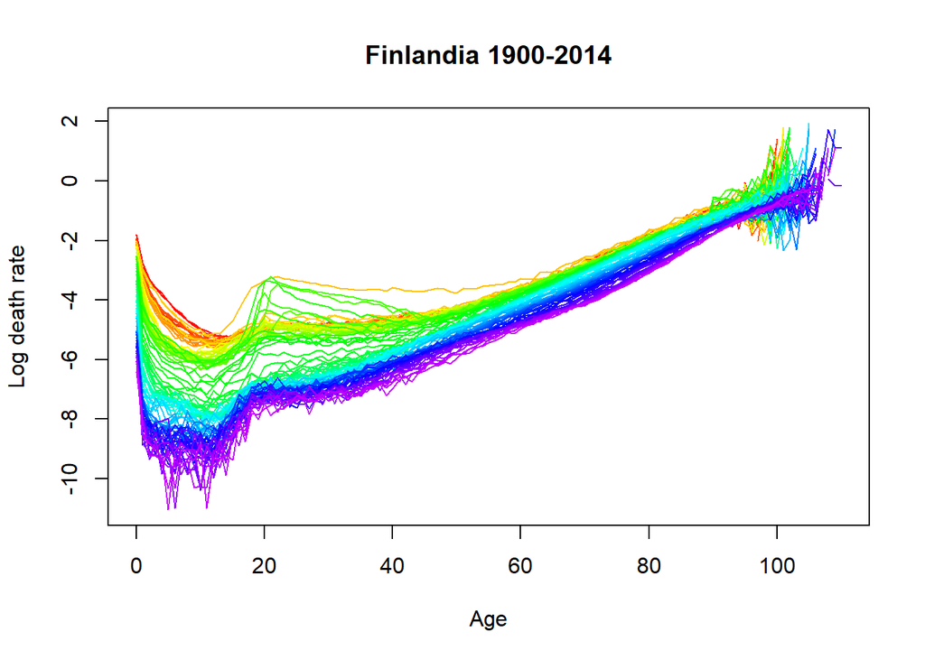

```r
#log dei tassi di mortalità

plot(fin, series=names(fin$rate)[3], year=1900:2014, main="Finlandia 1900-2014")
```

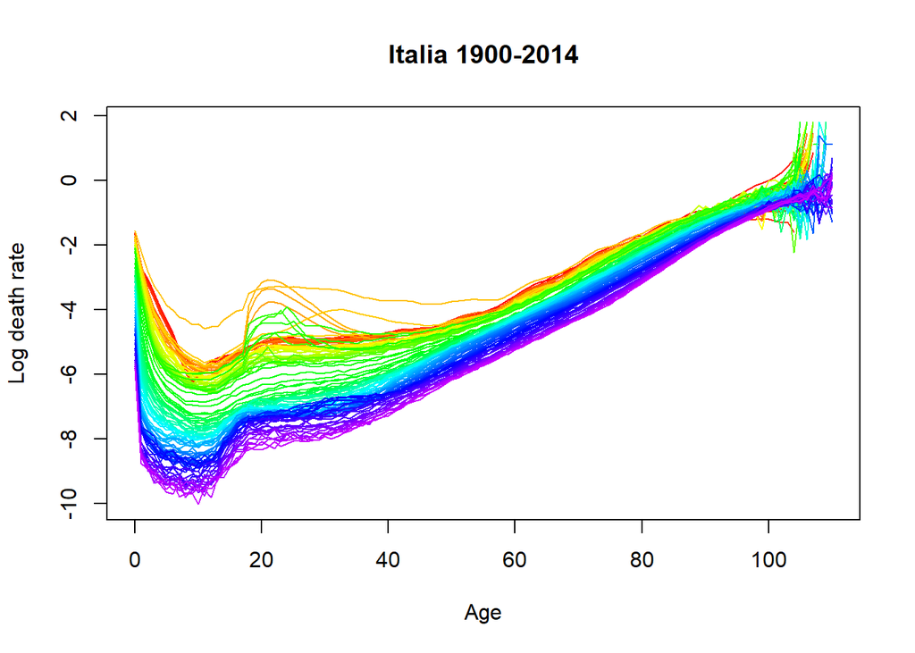

```r
plot(italy, series=names(italy$rate)[3], year=1900:2014, main="Italia 1900-2014")
```

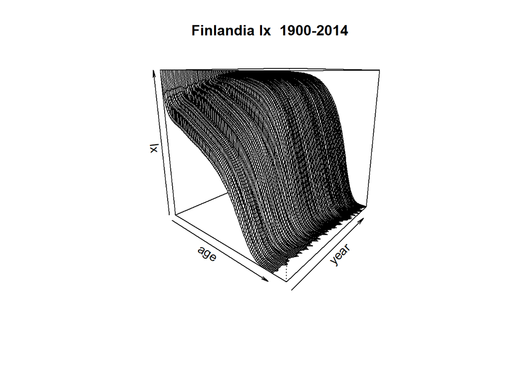

```r
#curve di sopravvivenza 3d
age <- fint.lt$age
year <- fint.lt$year
year <- year[-c(1:22)]
year <- year[-c(116)]
lx <- fint.lt$lx
lx <- lx[,-c(1:22,116)]

persp(age,year,lx, theta = 40, zlab = "lx", main = "Finlandia lx  1900-2014")
```

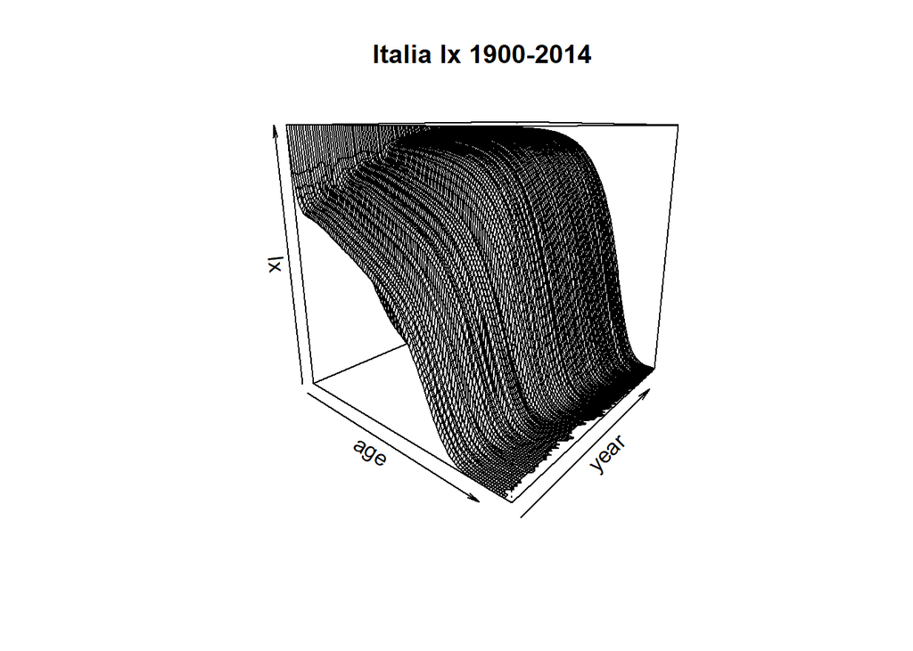

```r
age_it <- italyt.lt$age
year_it <- italyt.lt$year
year_it <- year_it[-c(1:28)]
lx_it <- italyt.lt$lx[,-c(1:28)]

persp(age_it,year_it,lx_it, theta = 40, zlab = "lx",ylab = "year",xlab = "age", main = "Italia lx 1900-2014")
```

Aspettativa di vita

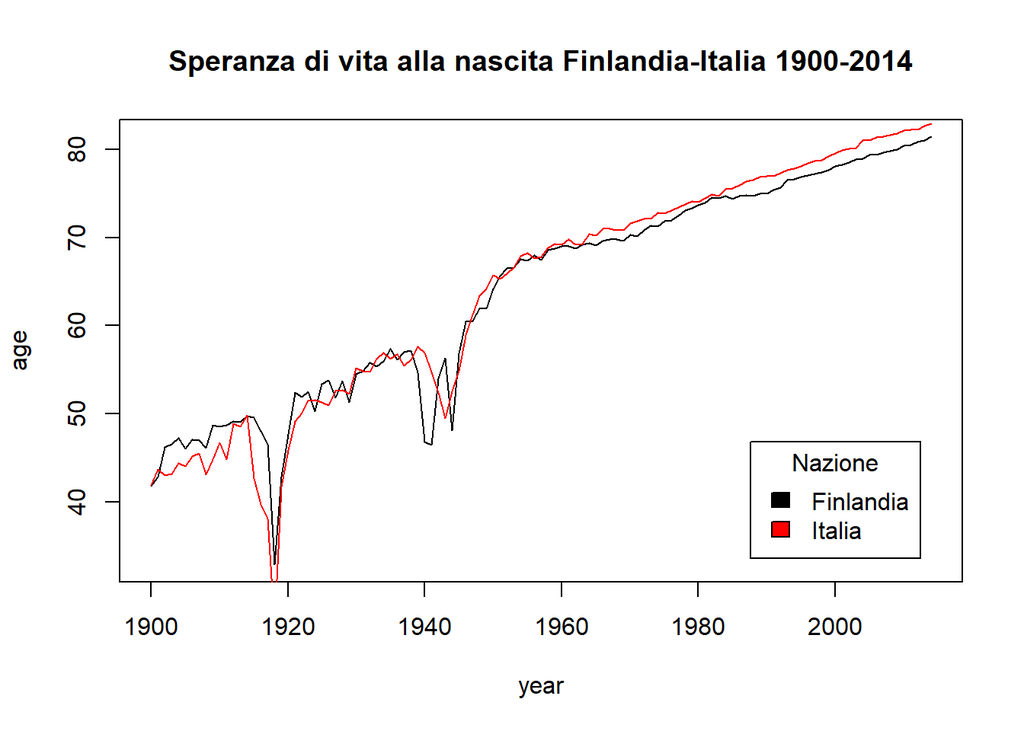

```r
#importo
fin0 <- hmd.e0("FIN", "gabelfra1@hotmail.it", "superorso1")
ita0 <- hmd.e0("ITA", "gabelfra1@hotmail.it", "superorso1")
#grafico
fin0_tot <- fin0[,3]
fin0_tot <- fin0_tot[-c(1:22,116)]
ita0_tot <- ita0[,3]
ita0_tot <- ita0_tot[-c(1:28)]

plot(year,fin0_tot,main="Speranza di vita alla nascita Finlandia-Italia 1900-2014",type = "lines",ylab = "age")
lines(year,ita0_tot,col="red")
legend("bottomright", inset=.05, title="Nazione",
    c("Finlandia","Italia"), fill=c("black","red"))
```

Tavola di mortalità Finlandia

```r
fint_2014.lt <- lifetable(fin, series = names(fin$rate)[3], years = fin$year[138], ages = fin$age, max.age = min(110, max(fin$age)), type = c("period"))
fint_2014.lt
```

```
## Period lifetable for Finland : total
##
## Year: 2015
##         mx     qx     lx     dx     Lx      Tx      ex
## 0   0.0017 0.0017 1.0000 0.0017 0.9984 81.4399 81.4399
## 1   0.0001 0.0001 0.9983 0.0001 0.9983 80.4415 80.5768
## 2   0.0001 0.0001 0.9982 0.0001 0.9982 79.4432 79.5837
## 3   0.0001 0.0001 0.9981 0.0001 0.9981 78.4450 78.5943
## 4   0.0001 0.0001 0.9980 0.0001 0.9980 77.4469 77.6007
## 5   0.0001 0.0001 0.9980 0.0001 0.9979 76.4490 76.6057
## 6   0.0000 0.0000 0.9979 0.0000 0.9979 75.4510 75.6118
## 7   0.0000 0.0000 0.9979 0.0000 0.9978 74.4532 74.6130
## 8   0.0000 0.0000 0.9978 0.0000 0.9978 73.4553 73.6166
## 9   0.0001 0.0001 0.9978 0.0001 0.9977 72.4576 72.6190
## 10  0.0000 0.0000 0.9977 0.0000 0.9977 71.4598 71.6250
```

[output cut: 100 more lines]

# Lancio modelli

```r
fin.LC1 <- lca(fin, series=names(fin$rate)[3], years=1960:2010,interpolate = TRUE)
italy.LC1 <- lca(italy, series=names(italy$rate)[3], years=1960:2010,interpolate = TRUE)
```

finlandia:

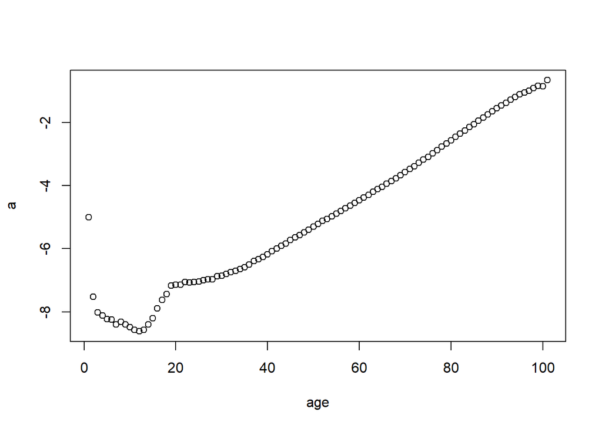

```r
plot(fin.LC1$ax,ylab = "a",xlab = "age")
```

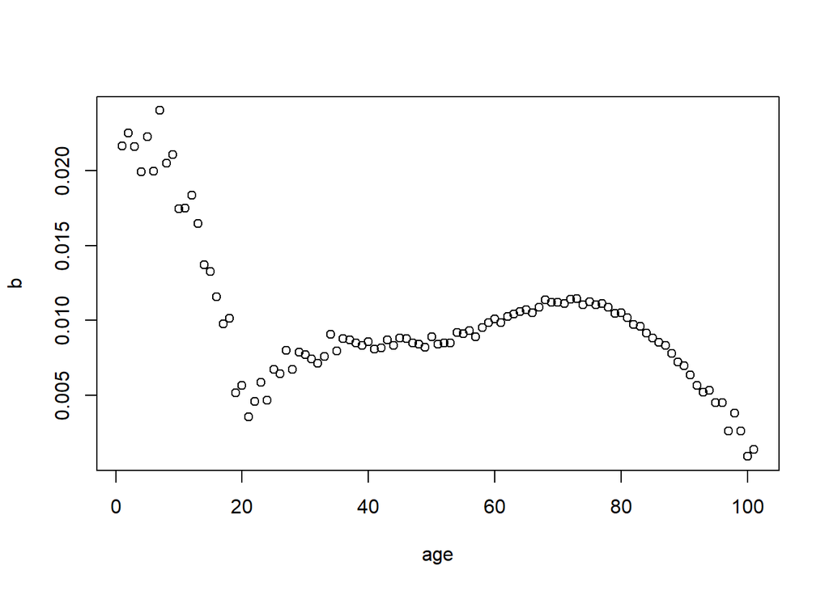

```r
plot(fin.LC1$bx,ylab = "b",xlab = "age")
```

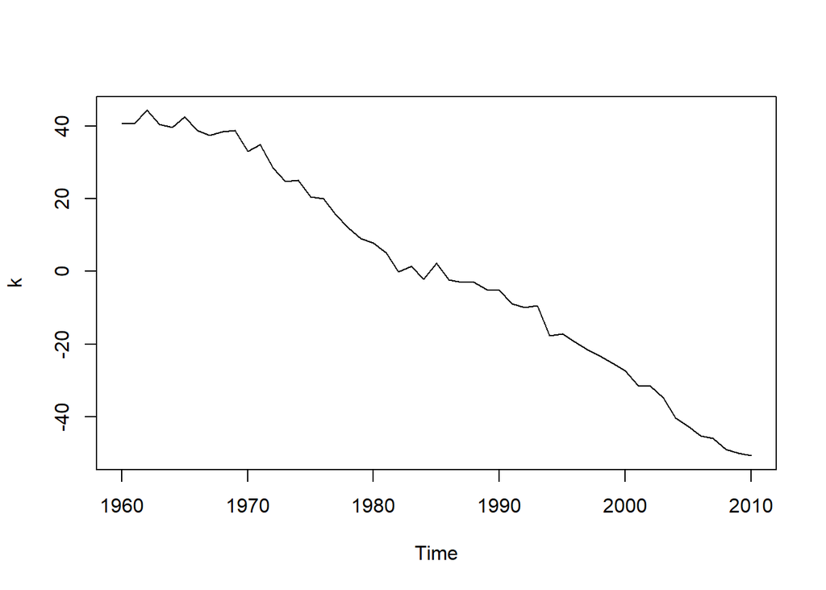

```r
plot(fin.LC1$kt,ylab = "k")
```

italia:

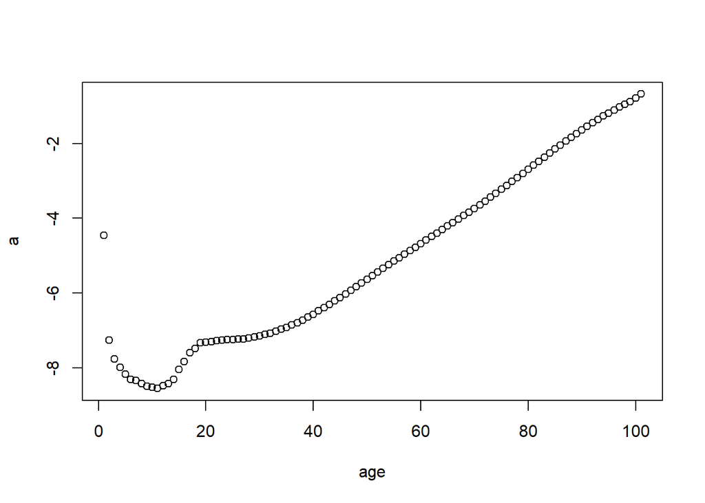

```r
plot(italy.LC1$ax,ylab = "a",xlab = "age")
```

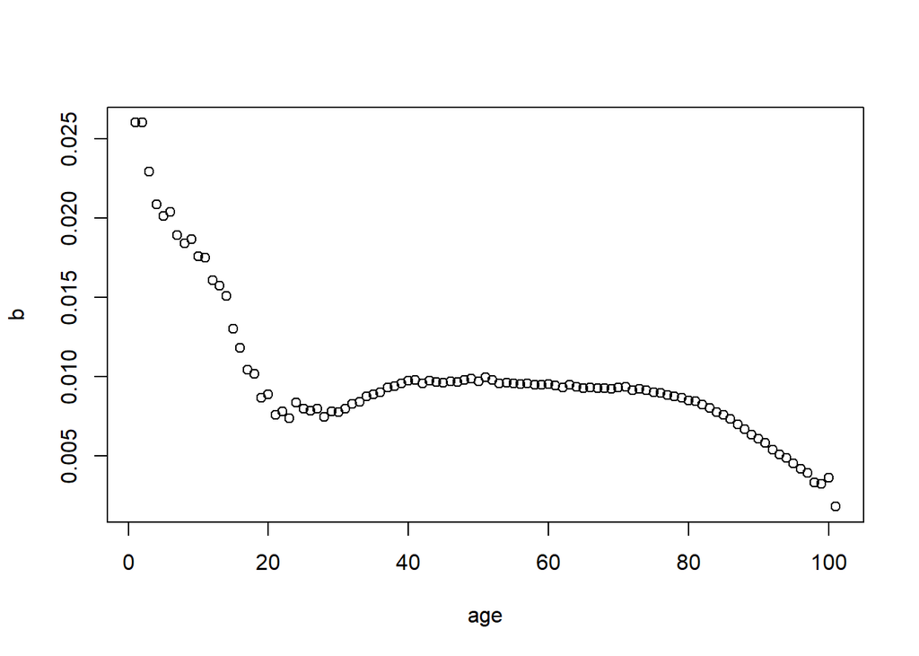

```r
plot(italy.LC1$bx,ylab = "b",xlab = "age")
```

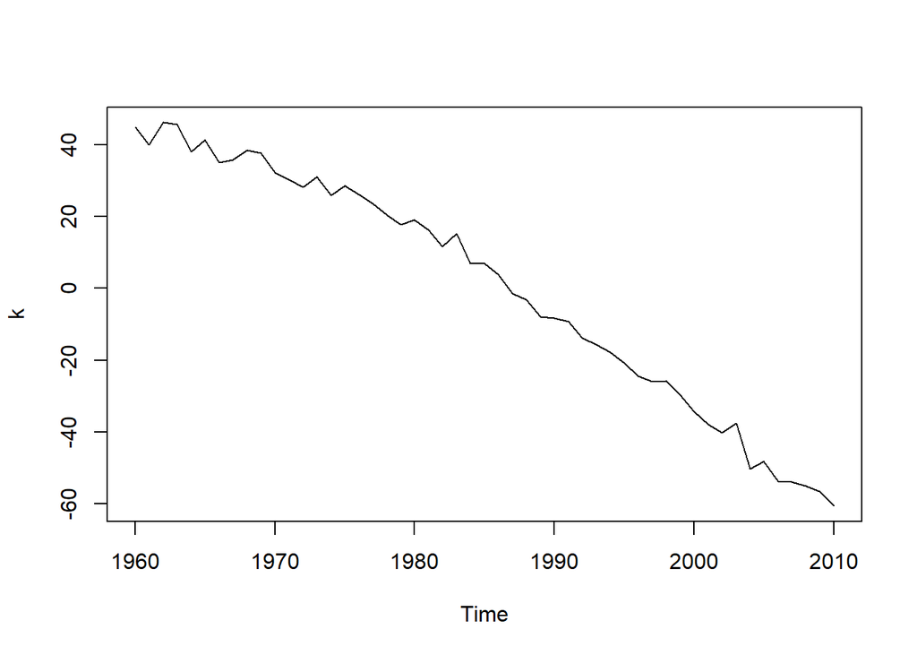

```r
plot(italy.LC1$kt,ylab = "k")
```

# Aspettativa di vita e0 femmine

```r
fin.LC1_f <- lca(fin, series=names(fin$rate)[1], years=1960:2010,interpolate = TRUE)
italy.LC1_f <- lca(italy, series=names(italy$rate)[1], years=1960:2010,interpolate = TRUE)
e_0_2010_2059_f <- life.expectancy(forecast(fin.LC1_f), type = c("period"))
e0_f <- life.expectancy(fin, series = names(fin$rate)[1],  years = fin$year, type = c("period"))
e_0_1872_2059_f <- c(e0_f, e_0_2010_2059_f)
```

Aspettativa di vita 2000 e 2030

```r
e_0_1872_2059_f["2000"]
```

```
##    2000
## 81.0305
```

```r
e_0_1872_2059_f["2030"]
```

```
##     2030
## 86.59285
```

Aspettativa di vita e0 maschi

```r
fin.LC1_m <- lca(fin, series=names(fin$rate)[2], years=1980:2010,interpolate = TRUE)
e_0_2010_2059_m <- life.expectancy(forecast(fin.LC1_m), type = c("period"))
e0_m <- life.expectancy(fin, series = names(fin$rate)[2],  years = fin$year, type = c("period"))
e_0_1872_2059_m <- c(e0_m, e_0_2010_2059_m)
```

Aspettativa di vita 2000 e 2030

```r
e_0_1872_2059_m["2000"]
```

```
##     2000
## 74.15112
```

```r
e_0_1872_2059_m["2030"]
```

```
##     2030
## 80.87202
```

Aspettativa di vita e20 femmine

```r
e_0_2010_2059_f <- life.expectancy(forecast(fin.LC1_f), type = c("period"),age = 20)
e0_f <- life.expectancy(fin, series = names(fin$rate)[1],  years = fin$year, type = c("period"),age = 20)
e_0_1872_2059_f <- c(e0_f, e_0_2010_2059_f)
```

Aspettativa di vita 2000 e 2030

```r
e_0_1872_2059_f["2000"]
```

```
##     2000
## 61.51893
```

```r
e_0_1872_2059_f["2030"]
```

```
##     2030
## 66.77244
```

Aspettativa di vita e20 maschi

```r
e_0_2010_2059_m <- life.expectancy(forecast(fin.LC1_m), type = c("period"),age = 20)
e0_m <- life.expectancy(fin, series = names(fin$rate)[2],  years = fin$year, type = c("period"),age = 20)
e_0_1872_2059_m <- c(e0_m, e_0_2010_2059_m)
```

Aspettativa di vita 2000 e 2030

```r
e_0_1872_2059_m["2000"]
```

```
##     2000
## 54.81045
```

```r
e_0_1872_2059_m["2030"]
```

```
##     2030
## 61.17009
```

Aspettativa di vita e60 femmine

```r
e_0_2010_2059_f <- life.expectancy(forecast(fin.LC1_f), type = c("period"),age = 60)
e0_f <- life.expectancy(fin, series = names(fin$rate)[1],  years = fin$year, type = c("period"),age = 60)
e_0_1872_2059_f <- c(e0_f, e_0_2010_2059_f)
```

Aspettativa di vita 2000 e 2030

```r
e_0_1872_2059_f["2000"]
```

```
##     2000
## 23.69978
```

```r
e_0_1872_2059_f["2030"]
```

```
##     2030
## 28.20085
```

Aspettativa di vita e60 maschi

```r
e_0_2010_2059_m <- life.expectancy(forecast(fin.LC1_m), type = c("period"),age = 60)
e0_m <- life.expectancy(fin, series = names(fin$rate)[2],  years = fin$year, type = c("period"),age = 60)
e_0_1872_2059_m <- c(e0_m, e_0_2010_2059_m)
```

Aspettativa di vita 2000 e 2030

```r
e_0_1872_2059_m["2000"]
```

```
##     2000
## 19.21286
```

```r
e_0_1872_2059_m["2030"]
```

```
##     2030
## 24.18663
```

Aspettativa di vita e80 femmine

```r
e_0_2010_2059_f <- life.expectancy(forecast(fin.LC1_f), type = c("period"),age = 80)
e0_f <- life.expectancy(fin, series = names(fin$rate)[1],  years = fin$year, type = c("period"),age = 80)
e_0_1872_2059_f <- c(e0_f, e_0_2010_2059_f)
```

Aspettativa di vita 2000 e 2030

```r
e_0_1872_2059_f["2000"]
```

```
##     2000
## 8.235871
```

```r
e_0_1872_2059_f["2030"]
```

```
##     2030
## 10.92626
```

Aspettativa di vita e80 maschi

```r
e_0_2010_2059_m <- life.expectancy(forecast(fin.LC1_m), type = c("period"),age = 80)
e0_m <- life.expectancy(fin, series = names(fin$rate)[2],  years = fin$year, type = c("period"),age = 80)
e_0_1872_2059_m <- c(e0_m, e_0_2010_2059_m)
```

Aspettativa di vita 2000 e 2030

```r
e_0_1872_2059_m["2000"]
```

```
##     2000
## 6.651352
```

```r
e_0_1872_2059_m["2030"]
```

```
##     2030
## 8.758703
```

## Passo ad aspettative di vita italia

Aspettativa di vita e0 femmine

```r
italy.LC1_f <- lca(italy, series=names(italy$rate)[1], years=1980:2010,interpolate = TRUE)
e_0_2010_2059_f <- life.expectancy(forecast(italy.LC1_f), type = c("period"))
e0_f <- life.expectancy(italy, series = names(italy$rate)[1],  years = italy$year, type = c("period"))
e_0_1872_2059_f <- c(e0_f, e_0_2010_2059_f)
```

Aspettativa di vita 2000 e 2030

```r
e_0_1872_2059_f["2000"]
```

```
##     2000
## 82.50352
```

```r
e_0_1872_2059_f["2030"]
```

```
##     2030
## 88.10547
```

Aspettativa di vita e0 maschi

```r
italy.LC1_m <- lca(italy, series=names(italy$rate)[2], years=1980:2010,interpolate = TRUE)
e_0_2010_2059_m <- life.expectancy(forecast(italy.LC1_m), type = c("period"))
e0_m <- life.expectancy(italy, series = names(italy$rate)[2],  years = italy$year, type = c("period"))
e_0_1872_2059_m <- c(e0_m, e_0_2010_2059_m)
```

Aspettativa di vita 2000 e 2030

```r
e_0_1872_2059_m["2000"]
```

```
##     2000
## 76.53381
```

```r
e_0_1872_2059_m["2030"]
```

```
##     2030
## 83.79532
```

Aspettativa di vita e20 femmine

```r
italy.LC1_f <- lca(italy, series=names(italy$rate)[1], years=1980:2010,interpolate = TRUE)
e_0_2010_2059_f <- life.expectancy(forecast(italy.LC1_f), type = c("period"),age = 20)
e0_f <- life.expectancy(italy, series = names(italy$rate)[1],  years = italy$year, type = c("period"),age=20)
e_0_1872_2059_f <- c(e0_f, e_0_2010_2059_f)
```

Aspettativa di vita 2000 e 2030

```r
e_0_1872_2059_f["2000"]
```

```
##     2000
## 63.08122
```

```r
e_0_1872_2059_f["2030"]
```

```
##     2030
## 68.27998
```

Aspettativa di vita e20 maschi

```r
italy.LC1_m <- lca(italy, series=names(italy$rate)[2], years=1980:2010,interpolate = TRUE)
e_0_2010_2059_m <- life.expectancy(forecast(italy.LC1_m), type = c("period"), age = 20)
e0_m <- life.expectancy(italy, series = names(italy$rate)[2],  years = italy$year, type = c("period"),age = 20)
e_0_1872_2059_m <- c(e0_m, e_0_2010_2059_m)
```

Aspettativa di vita 2000 e 2030

```r
e_0_1872_2059_m["2000"]
```

```
##    2000
## 57.2391
```

```r
e_0_1872_2059_m["2030"]
```

```
##    2030
## 64.0056
```

Aspettativa di vita e60 femmine

```r
italy.LC1_f <- lca(italy, series=names(italy$rate)[1], years=1980:2010,interpolate = TRUE)
e_0_2010_2059_f <- life.expectancy(forecast(italy.LC1_f), type = c("period"),age = 60)
e0_f <- life.expectancy(italy, series = names(italy$rate)[1],  years = italy$year, type = c("period"),age=60)
e_0_1872_2059_f <- c(e0_f, e_0_2010_2059_f)
```

Aspettativa di vita 2000 e 2030

```r
e_0_1872_2059_f["2000"]
```

```
##     2000
## 24.84409
```

```r
e_0_1872_2059_f["2030"]
```

```
##     2030
## 29.32123
```

Aspettativa di vita e60 maschi

```r
italy.LC1_m <- lca(italy, series=names(italy$rate)[2], years=1980:2010,interpolate = TRUE)
e_0_2010_2059_m <- life.expectancy(forecast(italy.LC1_m), type = c("period"), age = 60)
e0_m <- life.expectancy(italy, series = names(italy$rate)[2],  years = italy$year, type = c("period"),age = 60)
e_0_1872_2059_m <- c(e0_m, e_0_2010_2059_m)
```

Aspettativa di vita 2000 e 2030

```r
e_0_1872_2059_m["2000"]
```

```
##     2000
## 20.41677
```

```r
e_0_1872_2059_m["2030"]
```

```
##     2030
## 25.59951
```

Aspettativa di vita e80 femmine

```r
italy.LC1_f <- lca(italy, series=names(italy$rate)[1], years=1980:2010,interpolate = TRUE)
e_0_2010_2059_f <- life.expectancy(forecast(italy.LC1_f), type = c("period"),age = 80)
e0_f <- life.expectancy(italy, series = names(italy$rate)[1],  years = italy$year, type = c("period"),age=80)
e_0_1872_2059_f <- c(e0_f, e_0_2010_2059_f)
```

Aspettativa di vita 2000 e 2030

```r
e_0_1872_2059_f["2000"]
```

```
##     2000
## 9.167725
```

```r
e_0_1872_2059_f["2030"]
```

```
##    2030
## 11.8172
```

```r
italy.LC1_m <- lca(italy, series=names(italy$rate)[2], years=1980:2010,interpolate = TRUE)
e_0_2010_2059_m <- life.expectancy(forecast(italy.LC1_m), type = c("period"), age = 80)
e0_m <- life.expectancy(italy, series = names(italy$rate)[2],  years = italy$year, type = c("period"),age = 80)
e_0_1872_2059_m <- c(e0_m, e_0_2010_2059_m)
```

Aspettativa di vita 2000 e 2030

```r
e_0_1872_2059_m["2000"]
```

```
##     2000
## 7.329945
```

```r
e_0_1872_2059_m["2030"]
```

```
##    2030
## 9.53067
```

## Analisi del modello di Lee-Carter e degli altri modelli

```r
Ext_1 <- fin$pop$male[, 83:133]
Dxt_1 <- fin$rate$male[, 83:133]*Ext_1
ages_1=fin$age
years_1=fin$year[83:133]
```

Definisco i modelli

```r
LC <- lc( )
RH <- rh( )
```

Lancio i modelli

```r
LCfit_fin<- fit(LC, Dxt=Dxt_1, Ext=Ext_1, ages=ages_1, years=years_1 , ages.fit=60:89)
```

```
## StMoMo: Start fitting with gnm
## Initialising
## Running start-up iterations..
## Running main iterations.....
## Done
## StMoMo: Finish fitting with gnm
```

```r
RHfit_fin<- fit(RH, Dxt=Dxt_1, Ext=Ext_1, ages=ages_1, years=years_1 , ages.fit=60:89)
```

```
## StMoMo: Start fitting with gnm
## Initialising
## Running start-up iterations..
## Running main iterations....................................................
## ...............................
## Done
## StMoMo: Finish fitting with gnm
```

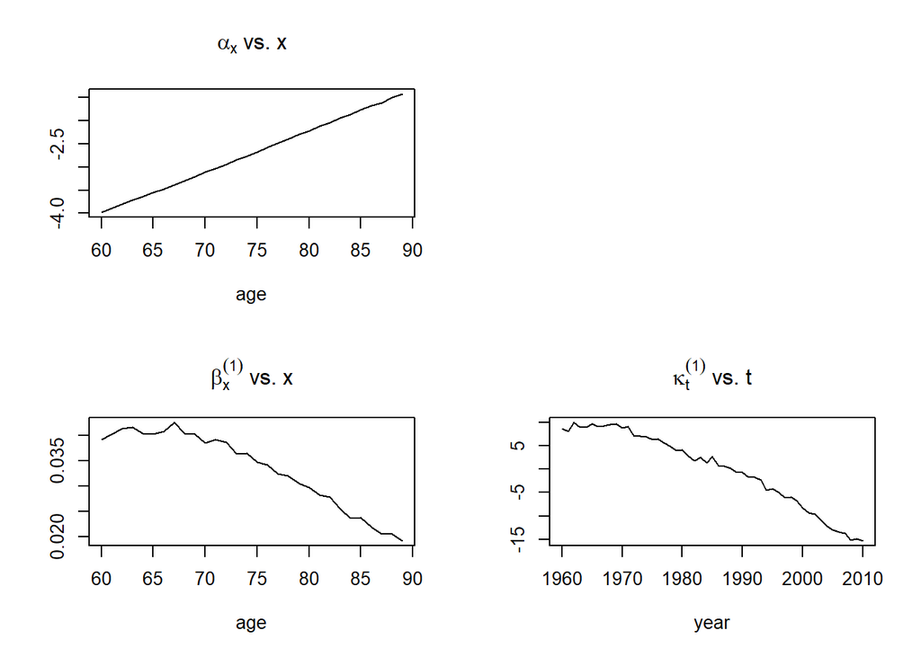

```r
plot(LCfit_fin)
```

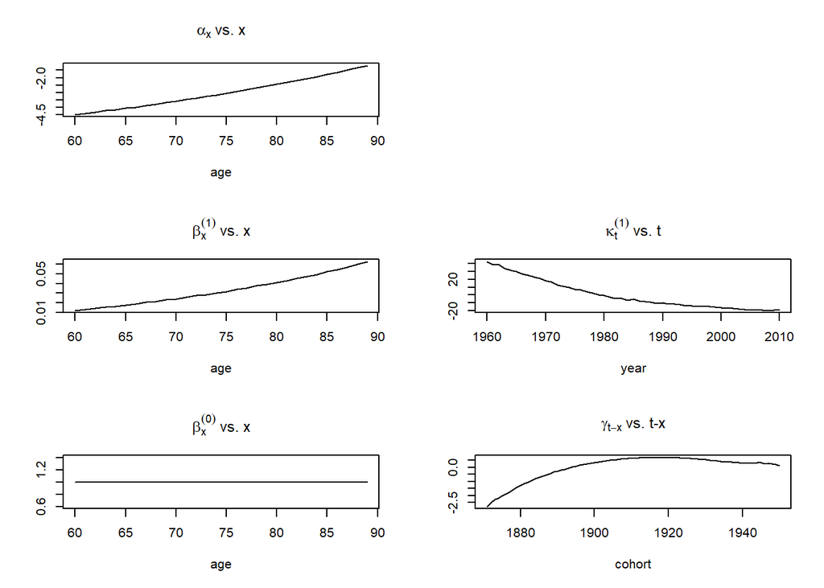

```r
plot(RHfit_fin)
```

Studio residui

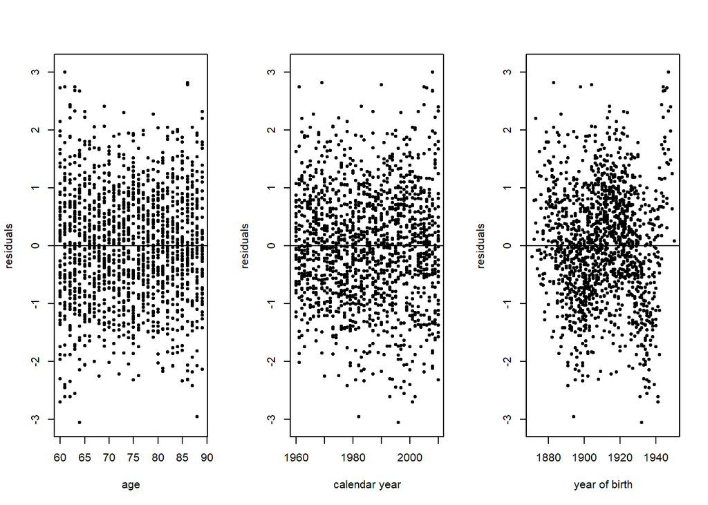

```r
LCres_fin<- residuals(LCfit_fin)
RHres_fin<- residuals(RHfit_fin)
plot(LCres_fin, type='scatter')
```

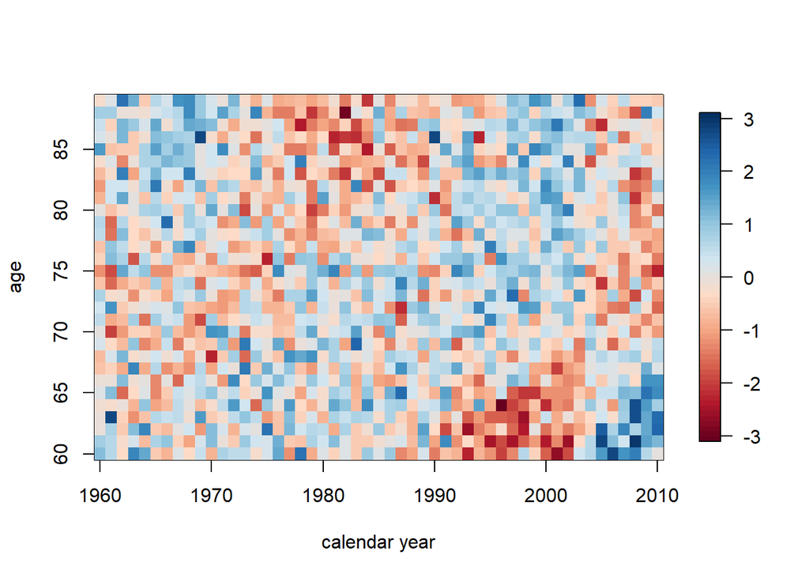

```r
plot(LCres_fin, type='colourmap')
```

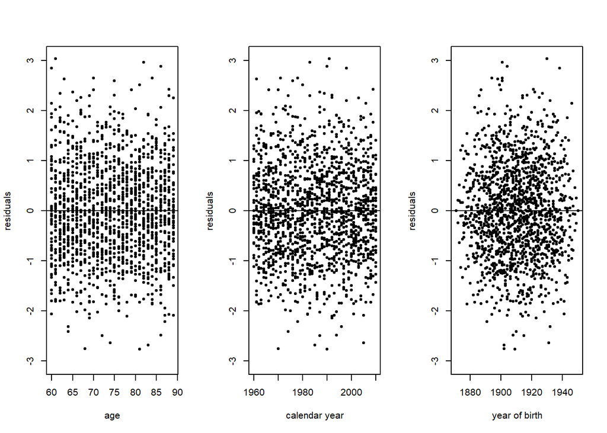

```r
plot(RHres_fin, type='scatter')
```

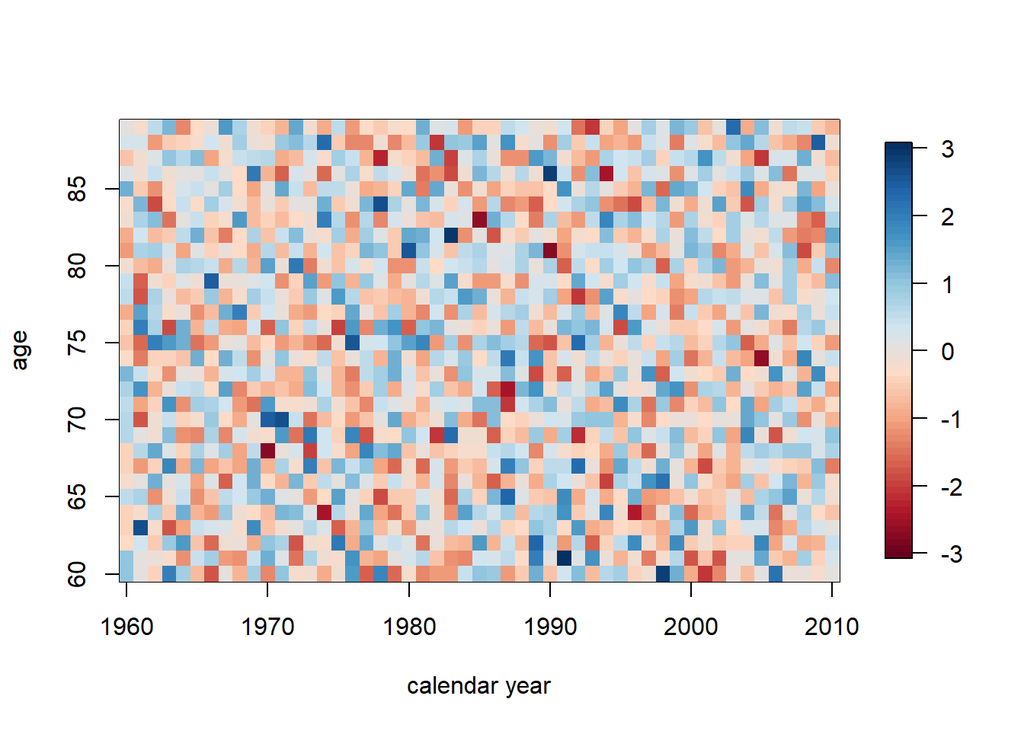

```r
plot(RHres_fin, type='colourmap')
```

BIC

```r
BIC_1 <- matrix ( nrow=1, ncol=2)
rownames (BIC_1) <- "BIC"
colnames (BIC_1) <- c("LC", "RH")
BIC_1[ 1 , 1 ] <- BIC(LCfit_fin)
BIC_1[ 1 , 2 ] <- BIC(RHfit_fin)

BIC_1
```

```
##           LC       RH
## BIC 15117.79 15025.56
```

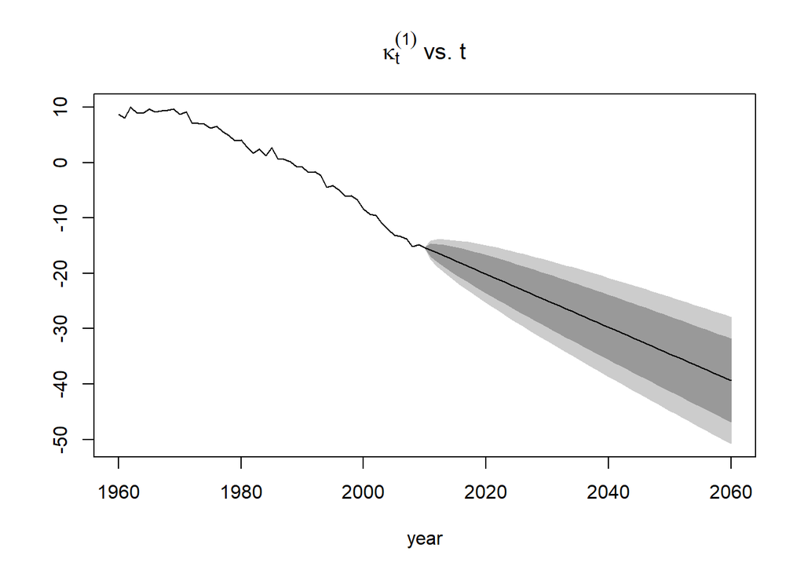

```r
LCfor_1<- forecast (LCfit_fin, h=50)
plot(LCfor_1, only.kt=TRUE)
```

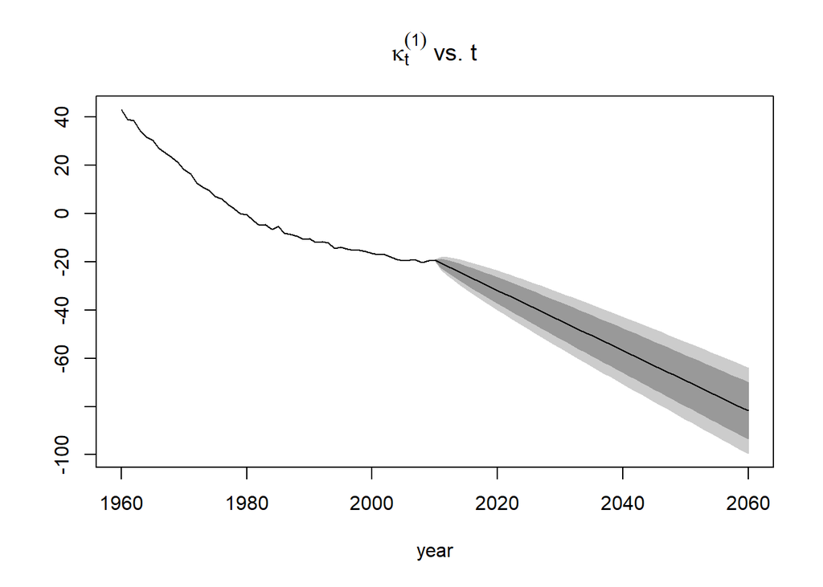

```r
RHfor_1<- forecast (RHfit_fin, h=50)
plot(RHfor_1, only.kt=TRUE)
```

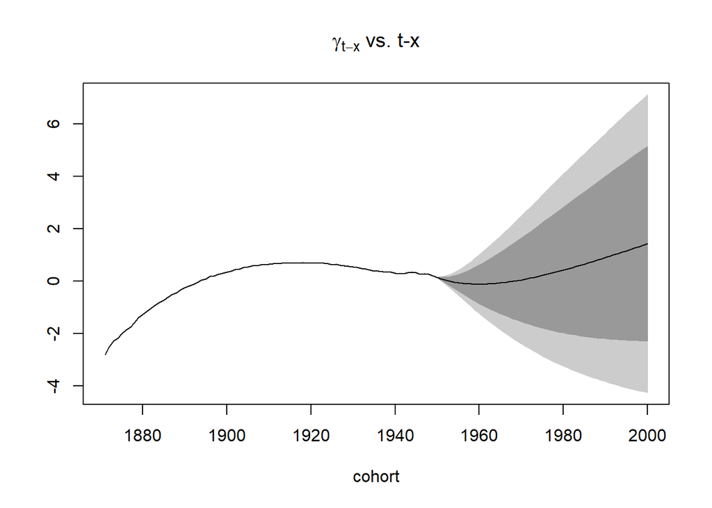

```r
plot(RHfor_1, only.gc=TRUE)
```

# Confronto out of sample

```r
Ext_2 <- fin$pop$male[, 83:123]
Dxt_2 <- fin$rate$male[, 83:123]*Ext_2
ages_2=fin$age
years_2=fin$year[83:123]


Ext_2_i <- italy$pop$male[, 89:129]
Dxt_2_i <- italy$rate$male[, 89:129]*Ext_2_i
ages_2_i=italy$age
years_2_i=italy$year[89:129]
```

Lancio i modelli

```r
LCfit_fin_2<- fit(LC, Dxt=Dxt_2, Ext=Ext_2, ages=ages_2, years=years_2 , ages.fit=60:89)
```

```
## StMoMo: Start fitting with gnm
## Initialising
## Running start-up iterations..
## Running main iterations.....
## Done
## StMoMo: Finish fitting with gnm
```

```r
RHfit_fin_2<- fit(RH, Dxt=Dxt_2, Ext=Ext_2, ages=ages_2, years=years_2 , ages.fit=60:89)
```

```
## StMoMo: Start fitting with gnm
## Initialising
## Running start-up iterations..
## Running main iterations....................................................
## ...........................................................................
## ...........................................................................
## ...........................................................................
## ...........................................................................
## ...........................................................................
## .........................................................................
## Done
```

```
## StMoMo: Finish fitting with gnm
```

```r
LCfit_ita_2<- fit(LC, Dxt=Dxt_2_i, Ext=Ext_2_i, ages=ages_2_i, years=years_2_i , ages.fit=60:89)
```

```
## StMoMo: Start fitting with gnm
## Initialising
## Running start-up iterations..
## Running main iterations.....
## Done
## StMoMo: Finish fitting with gnm
```

```r
RHfit_ita_2<- fit(RH, Dxt=Dxt_2_i, Ext=Ext_2_i, ages=ages_2_i, years=years_2_i , ages.fit=60:89)
```

```
## StMoMo: Start fitting with gnm
## Initialising
## Running start-up iterations..
## Running main iterations........................
## Done
## StMoMo: Finish fitting with gnm
```

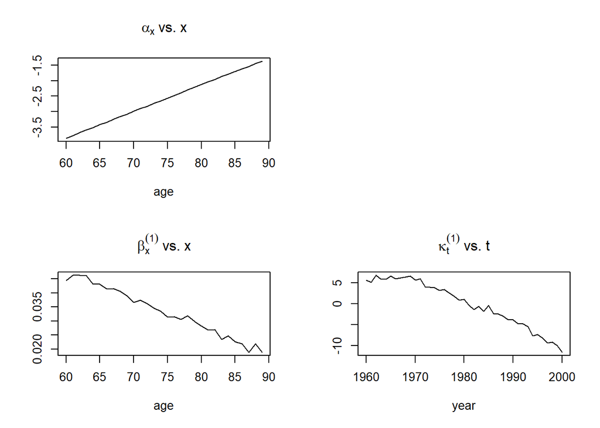

```r
plot(LCfit_fin_2)
```

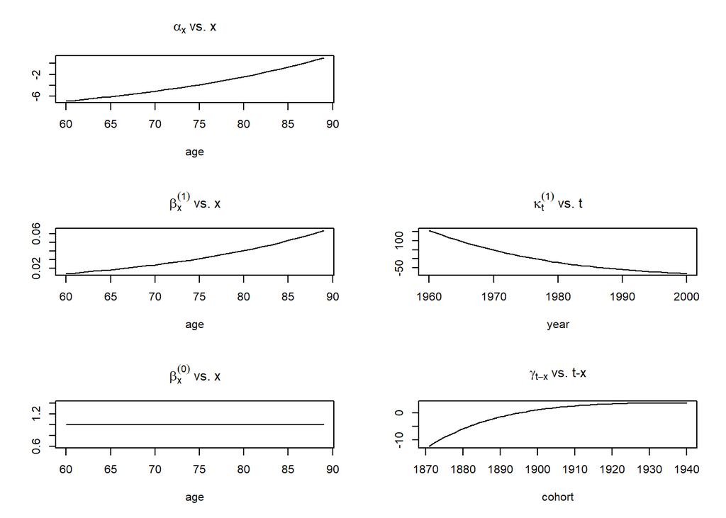

```r
plot(RHfit_fin_2)
```

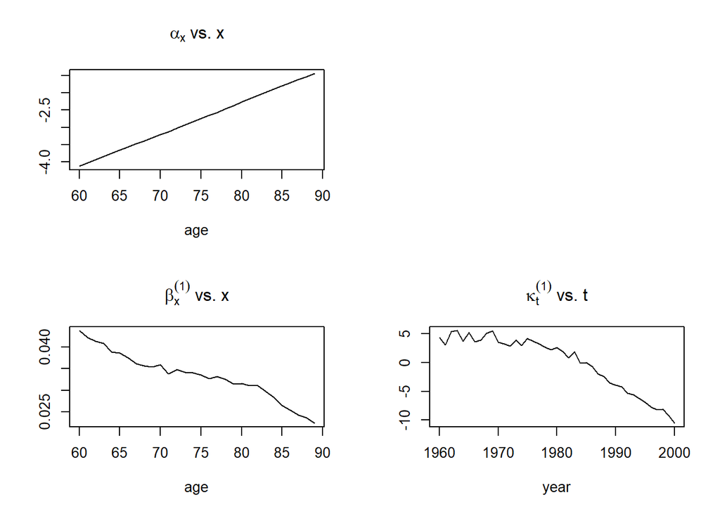

```r
plot(LCfit_ita_2)
```

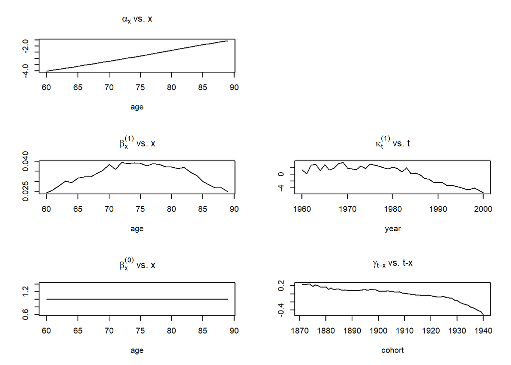

```r
plot(RHfit_ita_2)
```

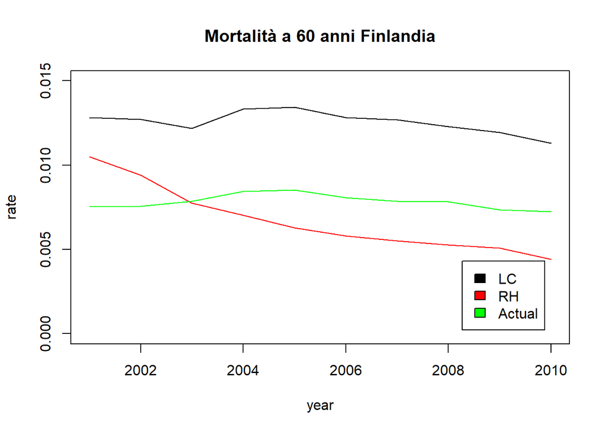

```r
nsim <- 100
LCsim <- simulate(LCfit_fin_2, nsim = nsim, h = 10)


RHsim <- simulate(RHfit_fin_2, nsim = nsim, h = 10)


LCsim_ita <- simulate(LCfit_ita_2, nsim = nsim, h = 10)


RHsim_ita <- simulate(RHfit_ita_2, nsim = nsim, h = 10)




plot(xlab = "year", ylab = "rate", main = "Mortalità a 60 anni Finlandia",LCsim$years, LCsim$rates["60", , 1], type = "l",ylim = range(0,0.015))
lines(LCsim$years, RHsim$rates["60", , 1], type = "l",col="red")
lines( LCsim$years , fin$rate$total[60, 124:133] , type = "l",col="green")
legend("bottomright", inset=.05,
    c("LC","RH","Actual"), fill=c("black","red","green"))
```

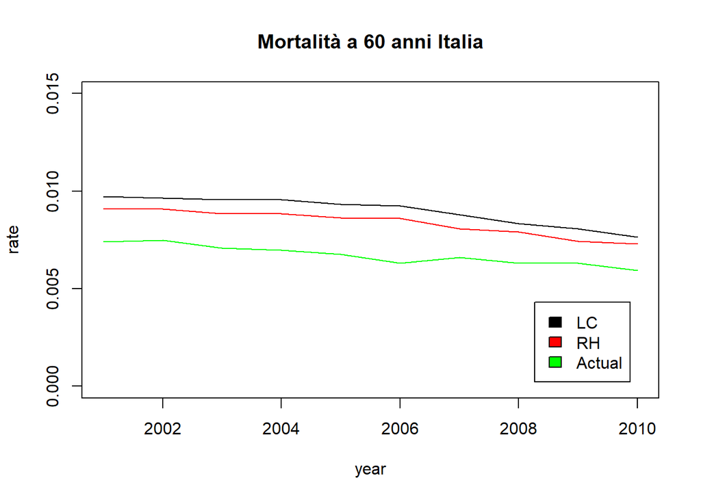

```r
plot(xlab = "year", ylab = "rate", main = "Mortalità a 60 anni Italia",LCsim_ita$years, LCsim_ita$rates["60", , 1], type = "l",ylim = range(0,0.015))
lines(LCsim_ita$years, RHsim_ita$rates["60", , 1], type = "l",col="red")
lines( LCsim_ita$years , italy$rate$total[60, 124:133] , type = "l",col="green")
legend("bottomright", inset=.05,
    c("LC","RH","Actual"), fill=c("black","red","green"))
```

Calcolo MSE

```r
MSE_fin_lc <- mean((LCsim$rates["60", , 1] - fin$rate$total[60, 124:133])^2)
MSE_fin_rh <- mean((RHsim$rates["60", , 1] - fin$rate$total[60, 124:133])^2)
MSE_ita_lc <- mean((LCsim_ita$rates["60", , 1] - italy$rate$total[60, 124:133])^2)
MSE_ita_rh <- mean((RHsim_ita$rates["60", , 1] - italy$rate$total[60, 124:133])^2)
MSE_fin_lc
```

```
## [1] 2.24727e-05
```

```r
MSE_fin_rh
```

```
## [1] 4.936047e-06
```

```r
MSE_ita_lc
```

```
## [1] 5.327225e-06
```

```r
MSE_ita_rh
```

```
## [1] 2.870306e-06
```